# Exploring the Online Retail Dataset

## 3.4 Inspect High-level-count Categorical Variables

With the raw data loaded up we now remove obvious unique or near-unique variables that are not amenable to basic exploration and plotting.

```r
coltype_lst <- create_coltype_list(data_tbl)

count_levels <- ~ .x %>% unique() %>% length()

catvar_valuecount_tbl <- data_tbl %>%
  summarise_at(coltype_lst$split$discrete, count_levels) %>%
  gather("var_name", "level_count") %>%
  arrange(-level_count)

print(catvar_valuecount_tbl)
```

```
## # A tibble: 13 x 2
##    var_name       level_count
##    <chr>                <int>
##  1 invoice_id           53628
##  2 customer_id           5943
##  3 description           5656
##  4 stock_code            5304
##  5 invoice_minute          60
##  6 invoice_woy             52
##  7 country                 43
##  8 invoice_dom             31
##  9 invoice_ym              25
## 10 invoice_hour            16
## 11 invoice_month           12
## 12 invoice_dow              7
## 13 excel_sheet              2
```

```r
row_count <- nrow(data_tbl)

cat(str_c("Dataset has ", row_count, " rows\n"))
```

```
## Dataset has 1043352 rows
```

Now that we a table of the counts of all the categorical variables we can automatically exclude unique variables from the exploration, as the level count will match the row count.

```r
unique_vars <- catvar_valuecount_tbl %>%
  filter(level_count == row_count) %>%
  pull(var_name)

print(unique_vars)
```

```
## character(0)
```

```r
explore_data_tbl <- data_tbl %>%
  select(-one_of(unique_vars))
```

Having removed the unique identifier variables from the dataset, we may also wish to exclude categoricals with high level counts also, so we create a vector of those variable names.

```r
highcount_vars <- catvar_valuecount_tbl %>%
  filter(level_count >= level_exclusion_threshold,
         level_count < row_count) %>%
  pull(var_name)

cat(str_c(highcount_vars, collapse = ", "))
```

```
## invoice_id, customer_id, description, stock_code
```

We now can continue doing some basic exploration of the data. We may also choose to remove some extra columns from the dataset.

```r
### You may want to comment out these next few lines to customise which
### categoricals are kept in the exploration.
drop_vars <- c(highcount_vars)

if (length(drop_vars) > 0) {
  explore_data_tbl <- explore_data_tbl %>%
      select(-one_of(drop_vars))

  cat(str_c(drop_vars, collapse = ", "))
}
```

```
## invoice_id, customer_id, description, stock_code
```

```r
data_tbl %>% write_rds("data/retail_data.rds")
```

# 4 Univariate Data Exploration

Now that we have loaded the data we can prepare it for some basic data exploration. We first exclude the variables that are unique identifiers or similar, and tehen split the remaining variables out into various categories to help with the systematic data exploration.

```r
coltype_lst <- create_coltype_list(explore_data_tbl)

print(coltype_lst)
```

```
## $split
## $split$continuous
## [1] "quantity"          "price"             "invoice_monthprop"
##
## $split$datetime
## [1] "invoice_date" "invoice_dttm"
##
## $split$discrete
## [1] "excel_sheet"    "country"        "invoice_month"  "invoice_dow"
## [5] "invoice_dom"    "invoice_hour"   "invoice_minute" "invoice_woy"
## [9] "invoice_ym"
##
## $split$logical
## [1] "cancellation"
##
##
## $columns
##       excel_sheet          quantity      invoice_date             price
##        "discrete"      "continuous"        "datetime"      "continuous"
##           country      cancellation      invoice_dttm     invoice_month
##        "discrete"         "logical"        "datetime"        "discrete"
##       invoice_dow       invoice_dom      invoice_hour    invoice_minute
##        "discrete"        "discrete"        "discrete"        "discrete"
##       invoice_woy        invoice_ym invoice_monthprop
##        "discrete"        "discrete"      "continuous"
```

## 4.1 Logical Variables

Logical variables only take two values: TRUE or FALSE. It is useful to see missing data as well though, so we also plot the count of those.

```
## --
## cancellation
```

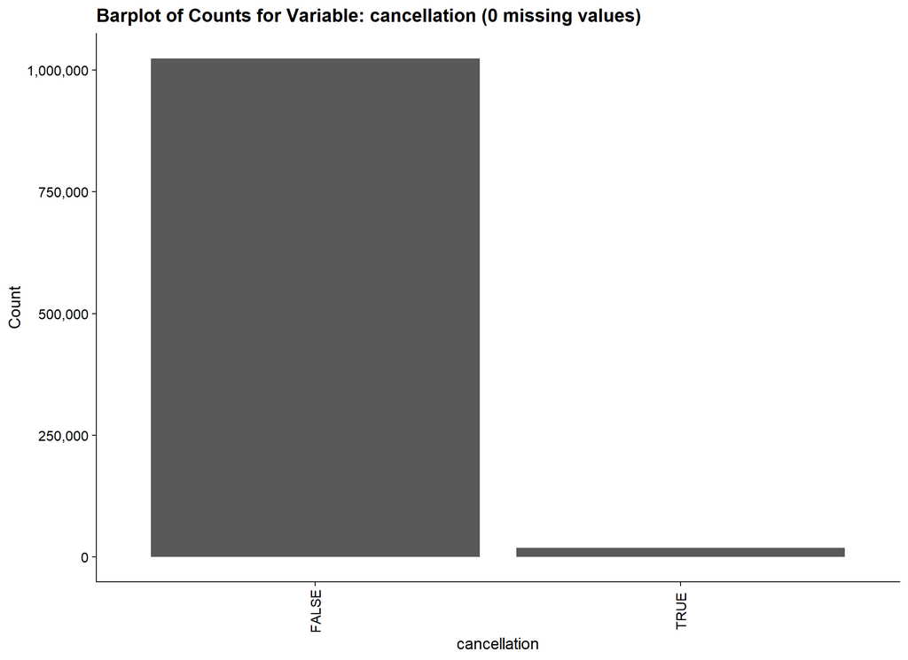

```r
logical_vars <- coltype_lst$split$logical %>% sort()

for (plot_varname in logical_vars) {
  cat("--\n")
  cat(str_c(plot_varname, "\n"))

  na_count <- explore_data_tbl %>% pull(!! plot_varname) %>% are_na() %>% sum()

  explore_plot <- ggplot(explore_data_tbl) +
    geom_bar(aes(x = !! sym(plot_varname))) +
    xlab(plot_varname) +
    ylab("Count") +
    scale_y_continuous(labels = label_comma()) +
    ggtitle(str_c("Barplot of Counts for Variable: ", plot_varname,
                  " (", na_count, " missing values)")) +
    theme(axis.text.x = element_text(angle = 90, vjust = 0.5))

  plot(explore_plot)
}
```

## 4.2 Numeric Variables

Numeric variables are usually continuous in nature, though we also have integer data.

```
## --
## invoice_monthprop
##    Min. 1st Qu.  Median    Mean 3rd Qu.    Max.
## 0.03226 0.26667 0.53333 0.51998 0.76667 1.00000
```

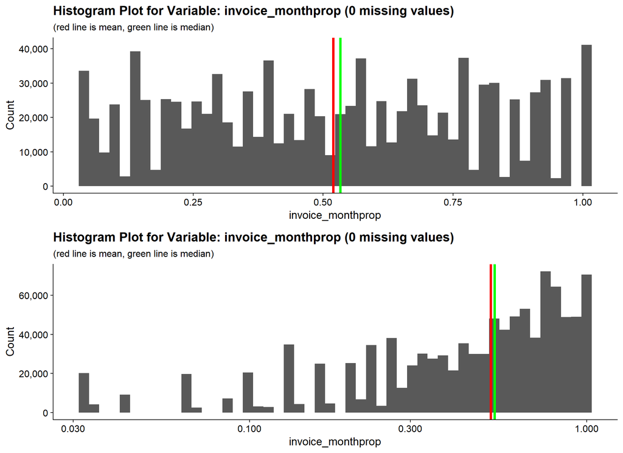

```
## --
## price
##      Min.   1st Qu.    Median      Mean   3rd Qu.      Max.
## -53594.36      1.25      2.10      4.68      4.15  38970.00
```

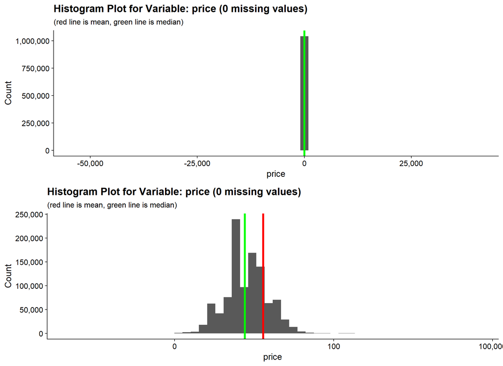

```
## --
## quantity
##      Min.   1st Qu.    Median      Mean   3rd Qu.      Max.
## -80995.00      1.00      3.00     10.07     10.00  80995.00
```

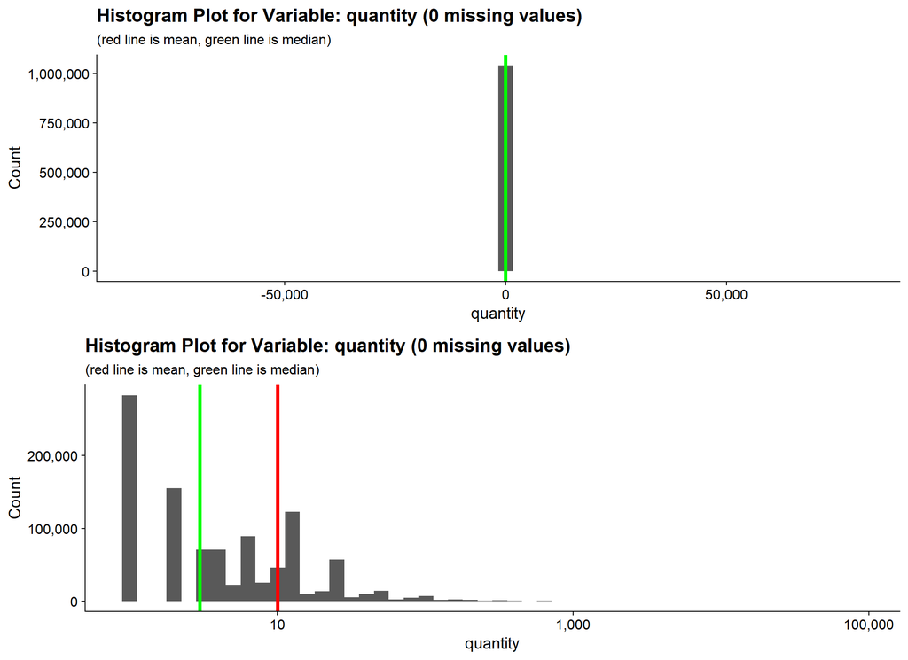

```r
numeric_vars <- coltype_lst$split$continuous %>% sort()

for (plot_varname in numeric_vars) {
  cat("--\n")
  cat(str_c(plot_varname, "\n"))

  plot_var <- explore_data_tbl %>% pull(!! plot_varname)
  na_count <- plot_var %>% are_na() %>% sum()

  plot_var %>% summary %>% print

  explore_plot <- ggplot(explore_data_tbl) +
    geom_histogram(aes(x = !! sym(plot_varname)),
                   bins = hist_bins_count) +
    geom_vline(xintercept = mean(plot_var, na.rm = TRUE),
               colour = "red",   size = 1.5) +
    geom_vline(xintercept = median(plot_var, na.rm = TRUE),
               colour = "green", size = 1.5) +
    xlab(plot_varname) +
    ylab("Count") +
    scale_y_continuous(labels = label_comma()) +
    ggtitle(str_c("Histogram Plot for Variable: ", plot_varname,
                  " (", na_count, " missing values)"),
            subtitle = "(red line is mean, green line is median)")

  explore_std_plot <- explore_plot + scale_x_continuous(labels = label_comma())
  explore_log_plot <- explore_plot + scale_x_log10     (labels = label_comma())

  plot_grid(explore_std_plot,
            explore_log_plot, nrow = 2) %>% print()
}
```

## 4.3 Categorical Variables

Categorical variables only have values from a limited, and usually fixed, number of possible values

```
## --
## country
```

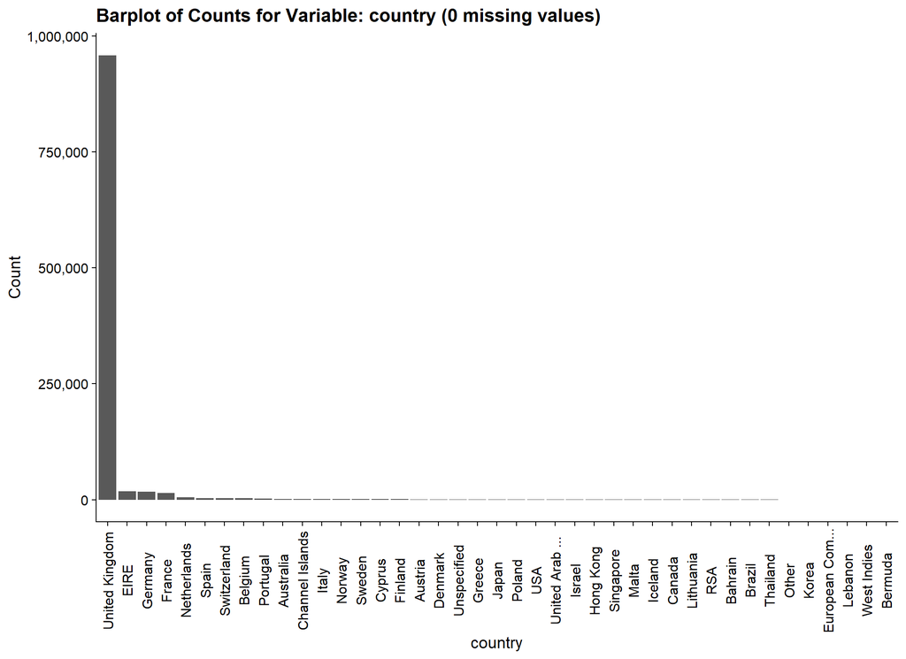

```
## --
## excel_sheet
```

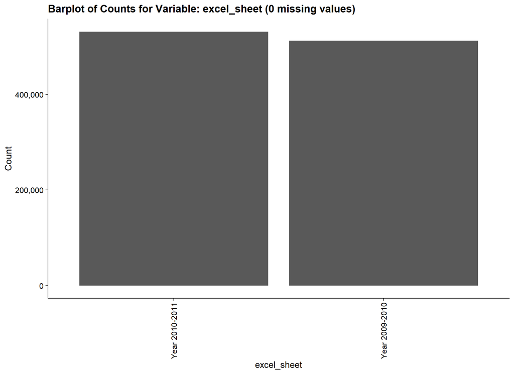

```
## --
## invoice_dom
```

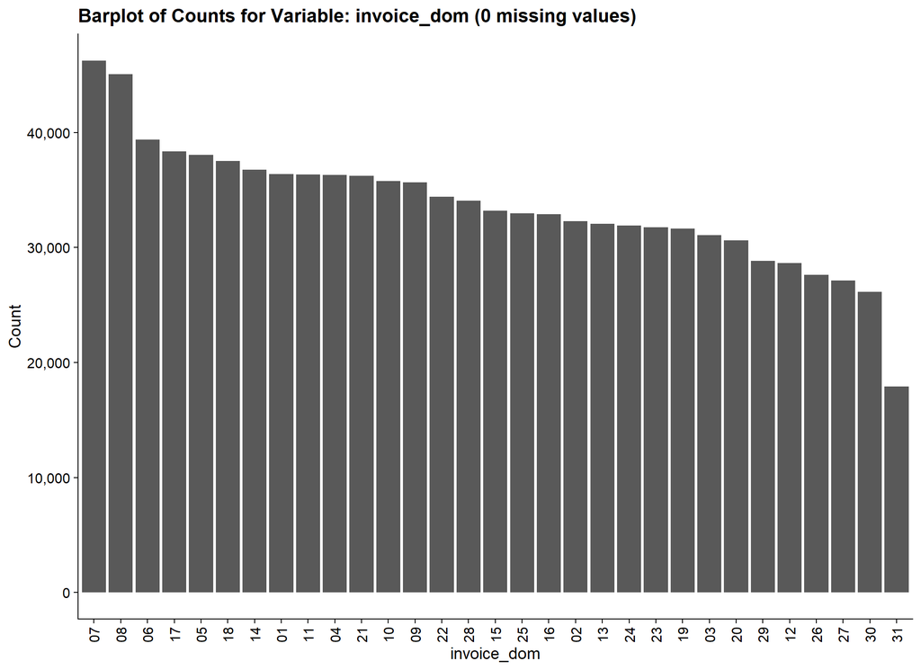

```
## --
## invoice_dow
```

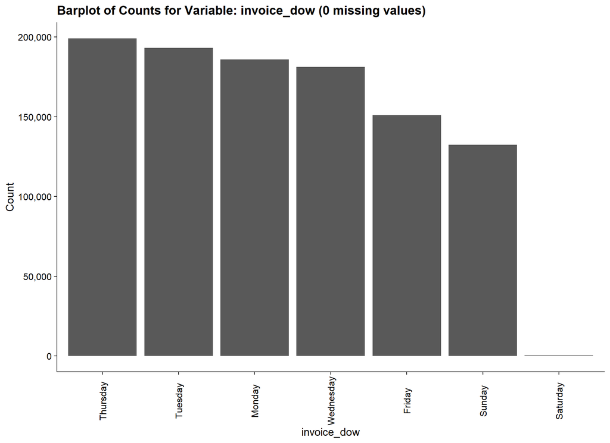

```
## --
## invoice_hour
```

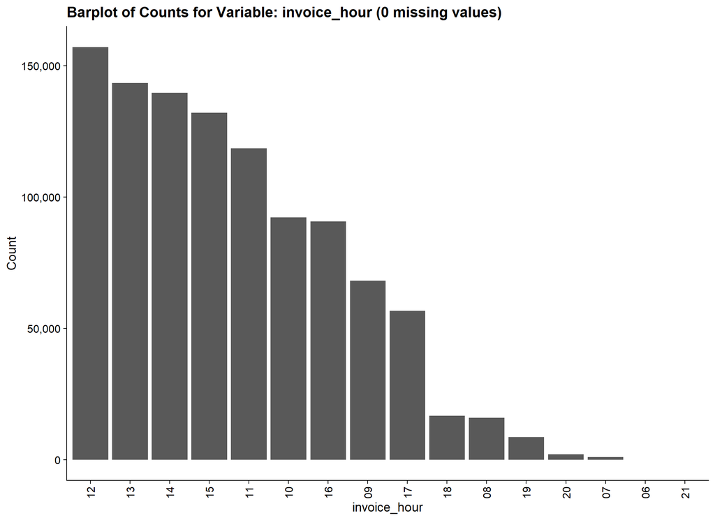

```
## --
## invoice_minute
```

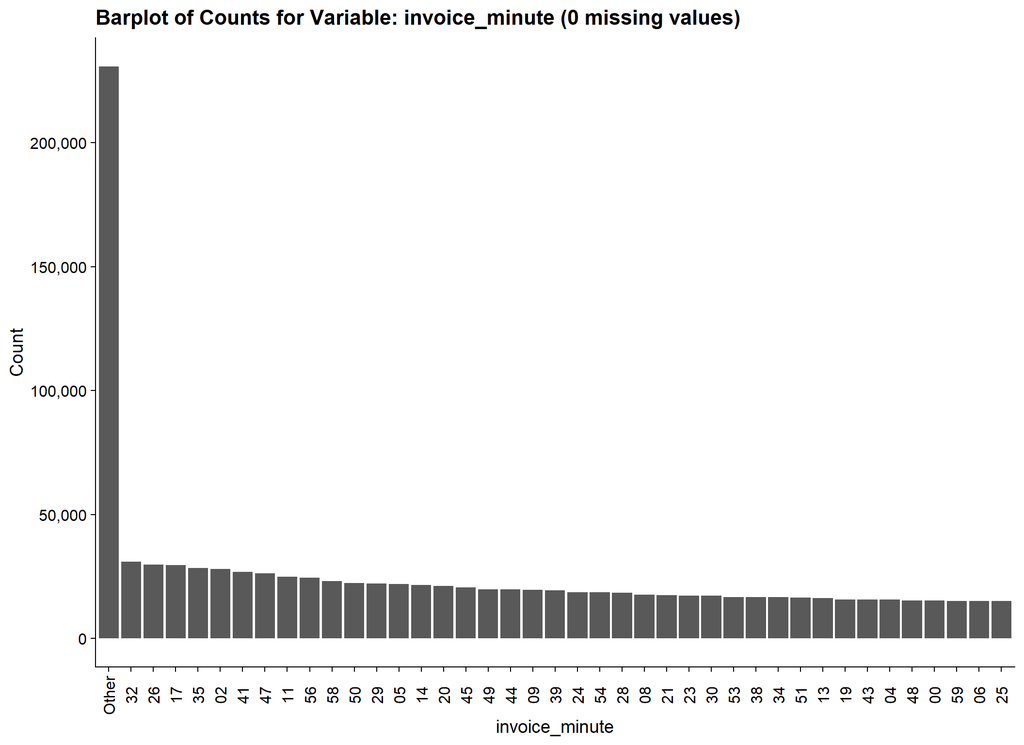

```
## --
## invoice_month
```

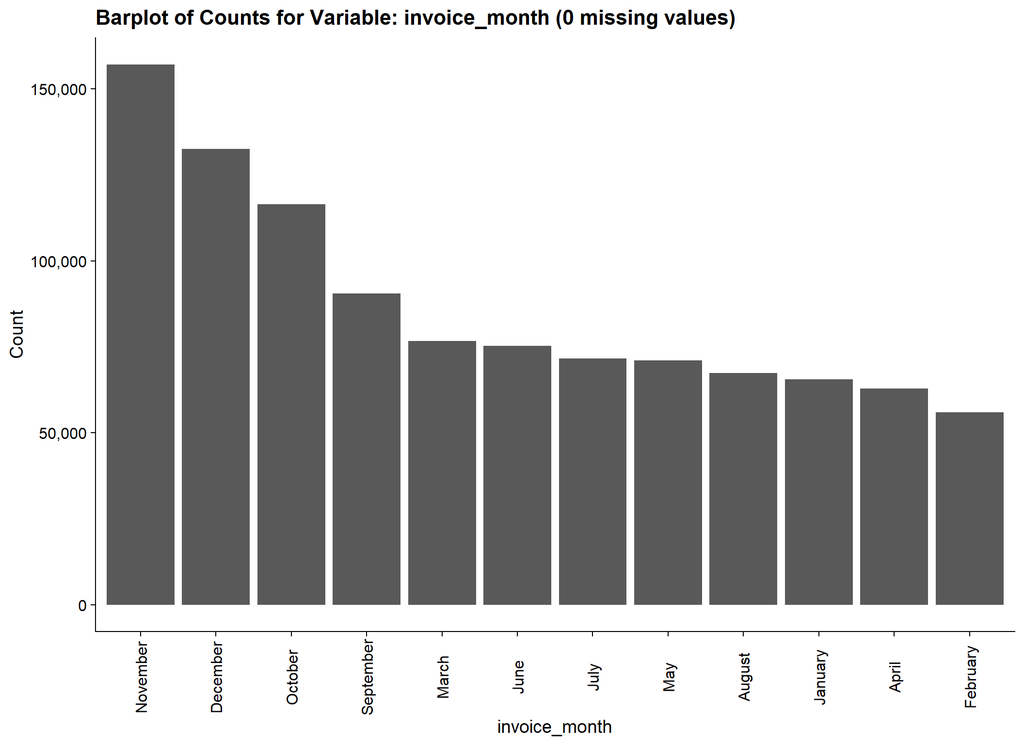

```
## --
## invoice_woy
```

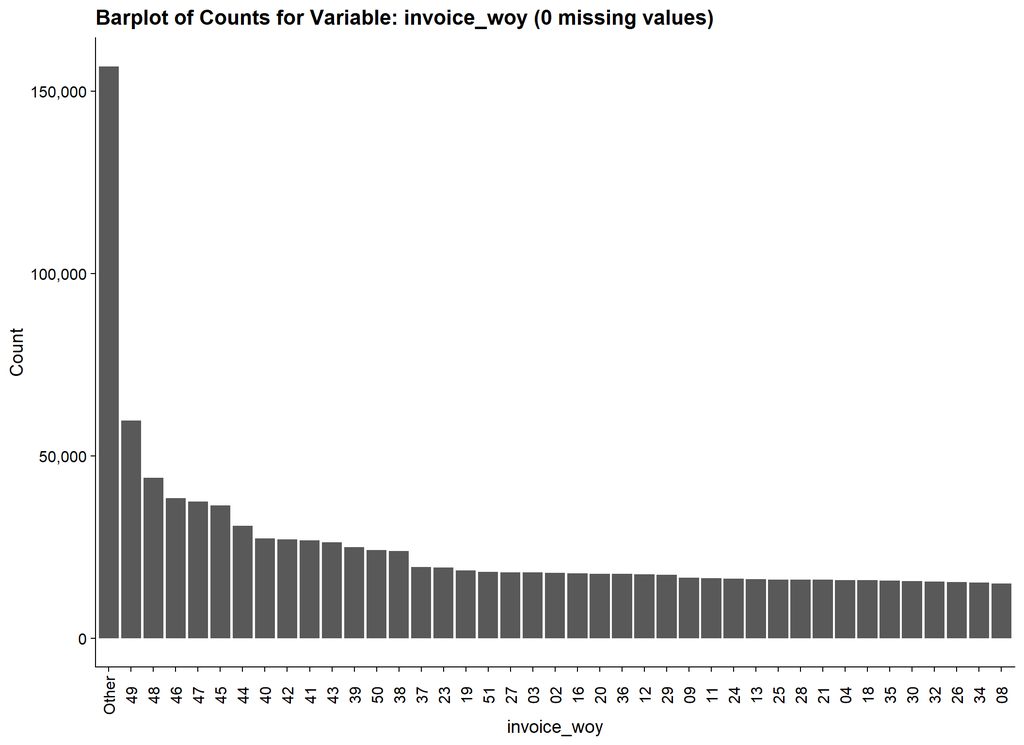

```
## --
## invoice_ym
```

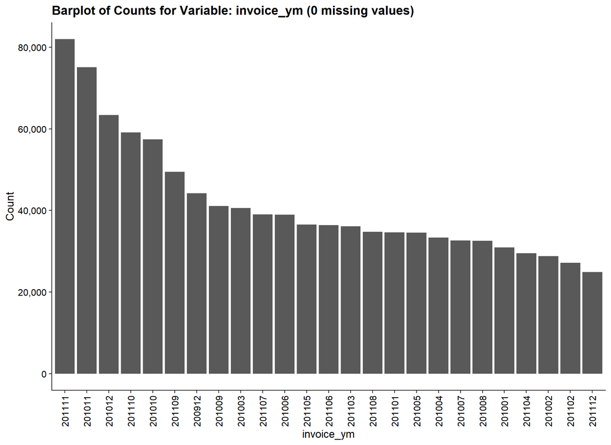

```r
categorical_vars <- coltype_lst$split$discrete %>% sort()

for (plot_varname in categorical_vars) {
  cat("--\n")
  cat(str_c(plot_varname, "\n"))

  na_count <- explore_data_tbl %>% pull(!! plot_varname) %>% are_na() %>% sum()

  plot_tbl <- explore_data_tbl %>%
    pull(!! plot_varname) %>%
    fct_lump(n = cat_level_count) %>%
    fct_count() %>%
    mutate(f = fct_relabel(f, str_trunc, width = 15))

  explore_plot <- ggplot(plot_tbl) +
    geom_bar(aes(x = fct_reorder(f, -n), weight = n)) +
    xlab(plot_varname) +
    ylab("Count") +
    scale_y_continuous(labels = label_comma()) +
    ggtitle(str_c("Barplot of Counts for Variable: ", plot_varname,
                  " (", na_count, " missing values)")) +
    theme(axis.text.x = element_text(angle = 90, vjust = 0.5))

  plot(explore_plot)
}
```

## 4.4 Date/Time Variables

Date/Time variables represent calendar or time-based data should as time of the day, a date, or a timestamp.

```
## --
## invoice_date
##         Min.      1st Qu.       Median         Mean      3rd Qu.         Max.
## "2009-12-01" "2010-07-08" "2010-12-07" "2011-01-02" "2011-07-22" "2011-12-09"
```

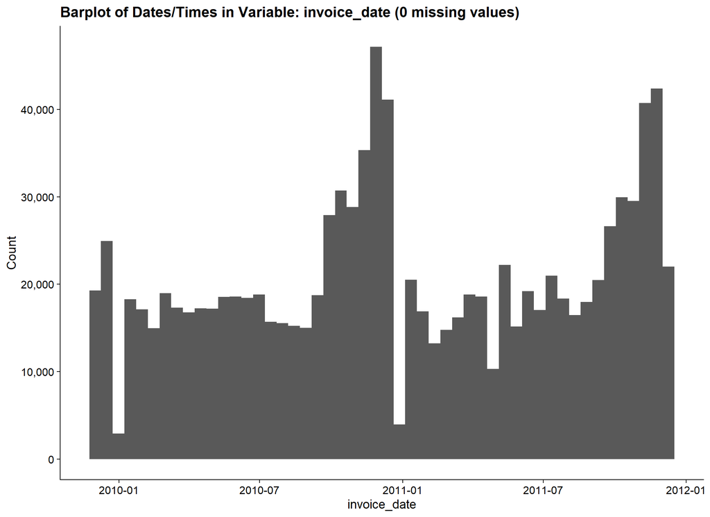

```
## --
## invoice_dttm
##                  Min.               1st Qu.                Median
## "2009-12-01 07:45:00" "2010-07-08 20:00:00" "2010-12-07 15:34:00"
##                  Mean               3rd Qu.                  Max.
## "2011-01-02 23:00:18" "2011-07-22 09:20:00" "2011-12-09 12:50:00"
```

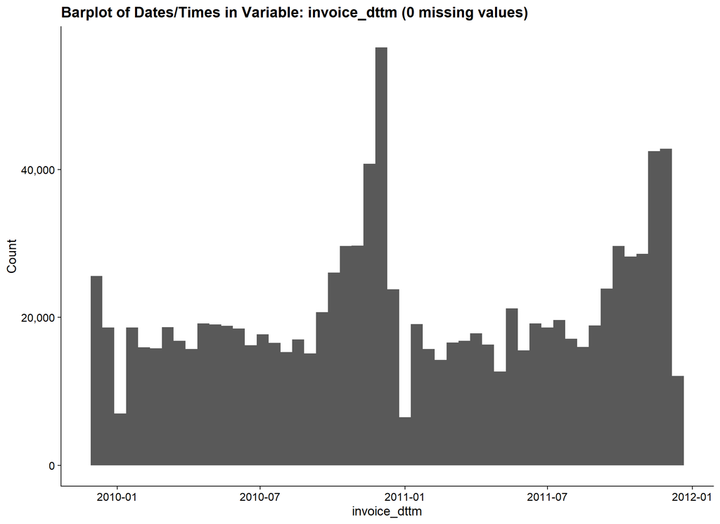

```r
datetime_vars <- coltype_lst$split$datetime %>% sort()

for (plot_varname in datetime_vars) {
  cat("--\n")
  cat(str_c(plot_varname, "\n"))

  plot_var <- explore_data_tbl %>% pull(!! plot_varname)
  na_count <- plot_var %>% are_na() %>% sum()

  plot_var %>% summary() %>% print()

  explore_plot <- ggplot(explore_data_tbl) +
    geom_histogram(aes(x = !! sym(plot_varname)),
                   bins = hist_bins_count) +
    xlab(plot_varname) +
    ylab("Count") +
    scale_y_continuous(labels = label_comma()) +
    ggtitle(str_c("Barplot of Dates/Times in Variable: ", plot_varname,
                  " (", na_count, " missing values)"))

  plot(explore_plot)
}
```

# 5 Bivariate Data Exploration

We now move on to looking at bivariate plots of the data set.

## 5.1 Facet Plots on Variables

A natural way to explore relationships in data is to create univariate visualisations facetted by a categorical value.

```r
facet_varname <- "excel_sheet"

facet_count_max <- 3
```

### 5.1.1 Logical Variables

For logical variables we facet on barplots of the levels, comparing TRUE, FALSE and missing data.

```
## --
## cancellation
```

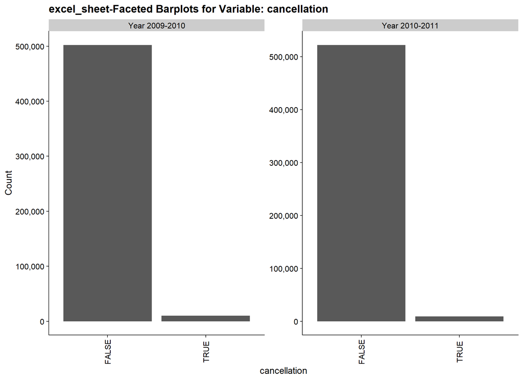

```r
logical_vars <- logical_vars[!logical_vars %in% facet_varname] %>% sort()


for (plot_varname in logical_vars) {
  cat("--\n")
  cat(str_c(plot_varname, "\n"))

  plot_tbl <- data_tbl %>% filter(!are_na(!! plot_varname))

  explore_plot <- ggplot(plot_tbl) +
    geom_bar(aes(x = !! sym(plot_varname))) +
    facet_wrap(facet_varname, scales = "free") +
    xlab(plot_varname) +
    ylab("Count") +
    scale_y_continuous(labels = label_comma()) +
    ggtitle(str_c(facet_varname, "-Faceted Barplots for Variable: ",
                  plot_varname)) +
    theme(axis.text.x = element_text(angle = 90, vjust = 0.5))

  plot(explore_plot)
}
```

### 5.1.2 Numeric Variables

For numeric variables, we facet on histograms of the data.

```
## --
## invoice_monthprop
```

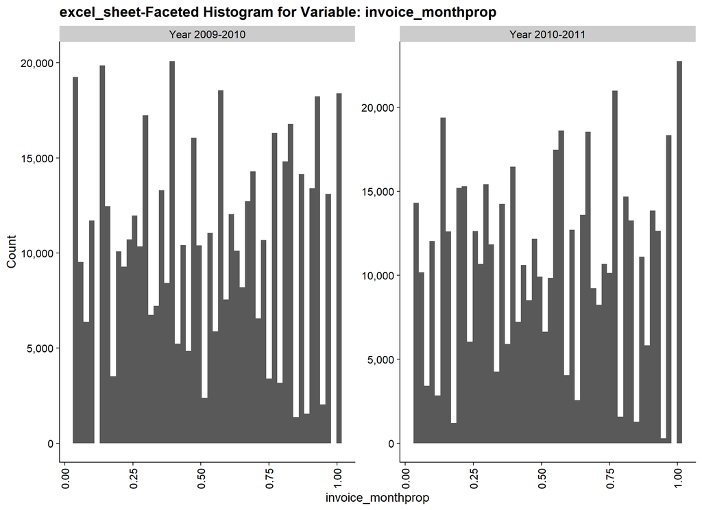

```
## --
## price
```

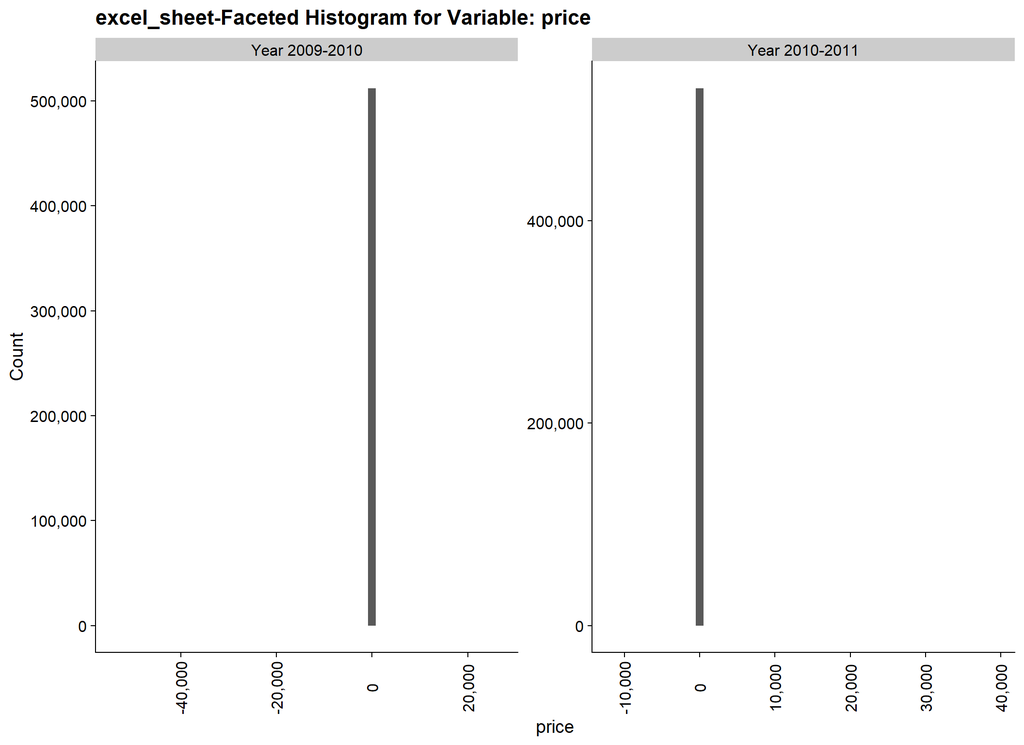

```
## --
## quantity
```

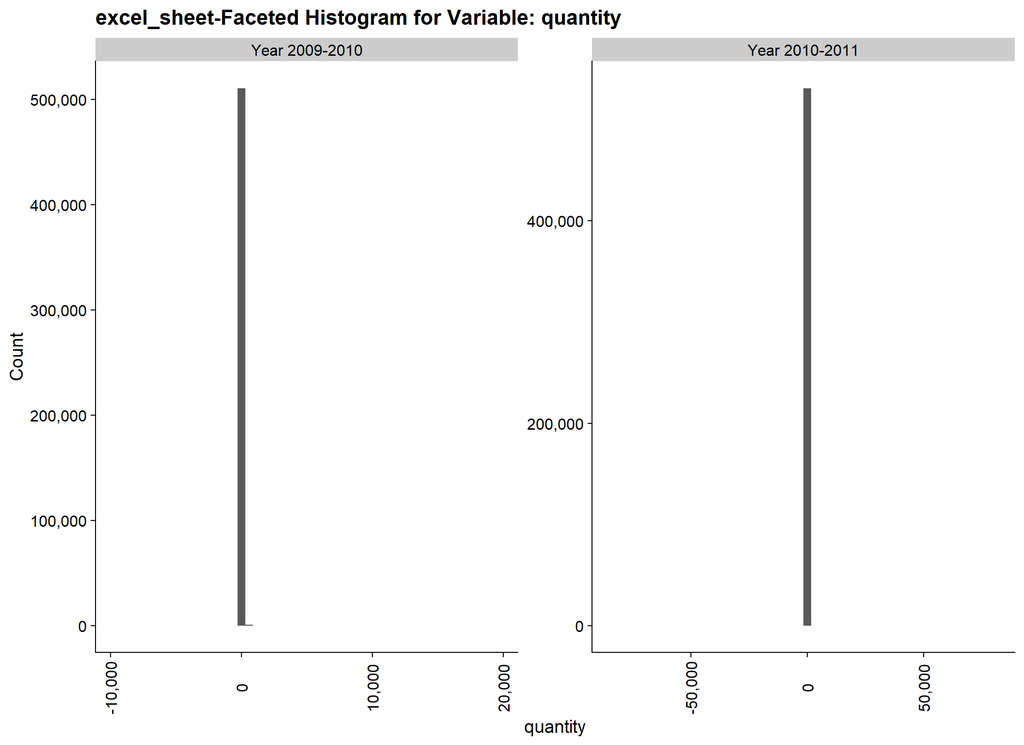

```r
for (plot_varname in numeric_vars) {
  cat("--\n")
  cat(str_c(plot_varname, "\n"))

  plot_tbl <- data_tbl %>% filter(!are_na(!! plot_varname))

  explore_plot <- ggplot(plot_tbl) +
    geom_histogram(aes(x = !! sym(plot_varname)),
                   bins = hist_bins_count) +
    facet_wrap(facet_varname, scales = "free") +
    xlab(plot_varname) +
    ylab("Count") +
    scale_x_continuous(labels = label_comma()) +
    scale_y_continuous(labels = label_comma()) +
    ggtitle(str_c(facet_varname, "-Faceted Histogram for Variable: ",
                  plot_varname)) +
    theme(axis.text.x = element_text(angle = 90, vjust = 0.5))

  print(explore_plot)
}
```

### 5.1.3 Categorical Variables

We treat categorical variables like logical variables, faceting the barplots of the different levels of the data.

```
## --
## country
```

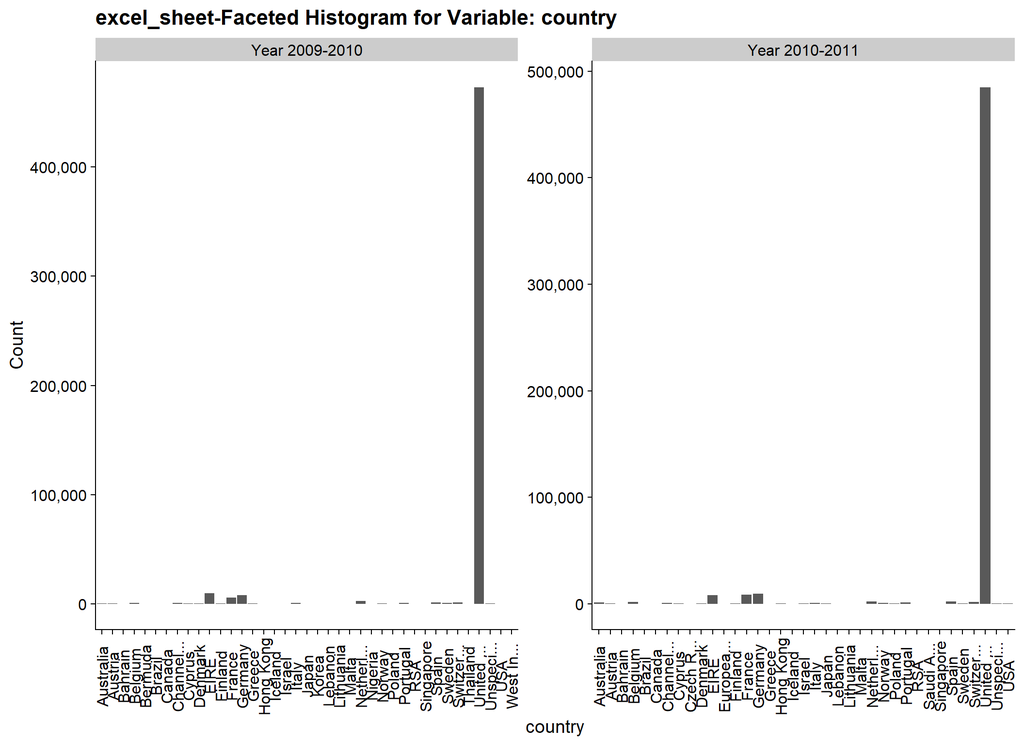

```
## --
## invoice_dom
```

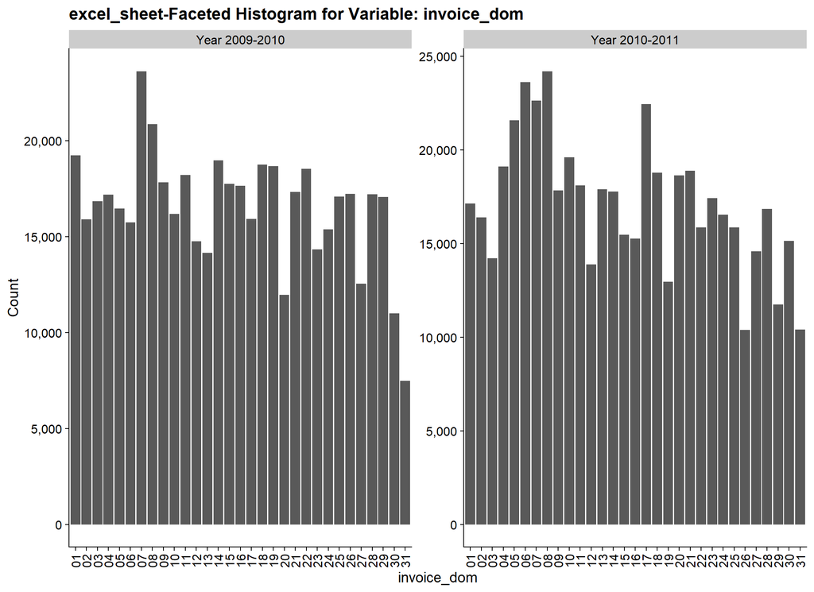

```
## --
## invoice_dow
```

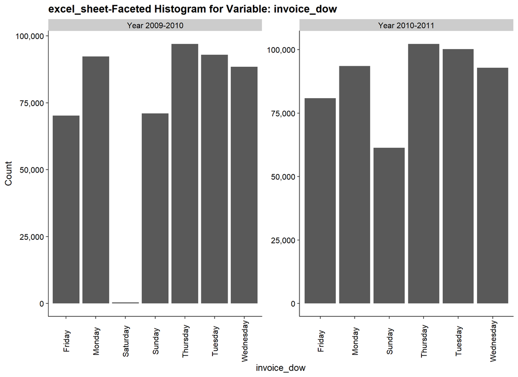

```
## --
## invoice_hour
```

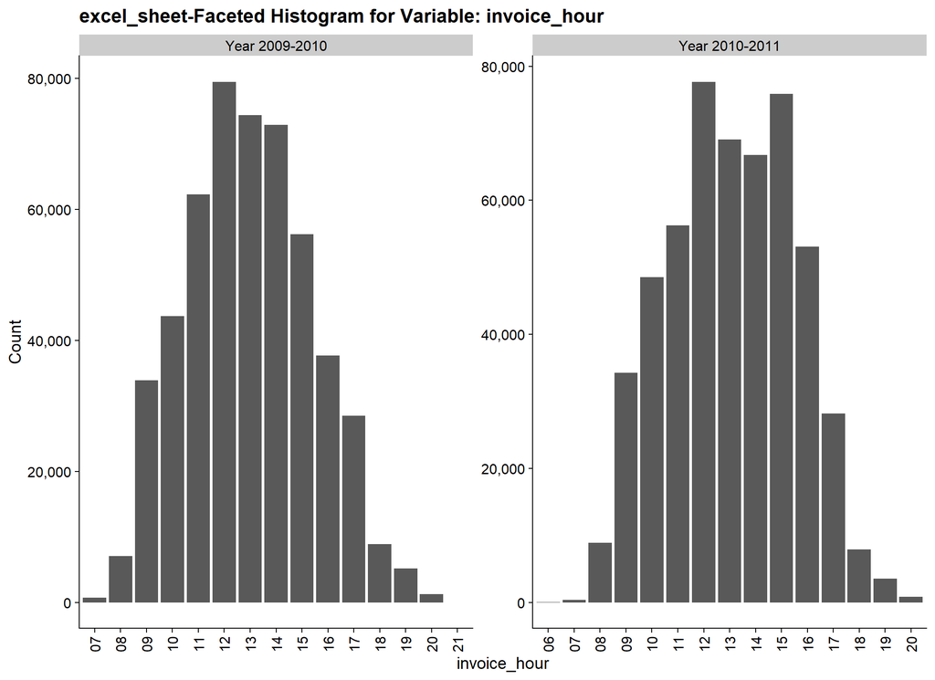

```
## --
## invoice_minute
```

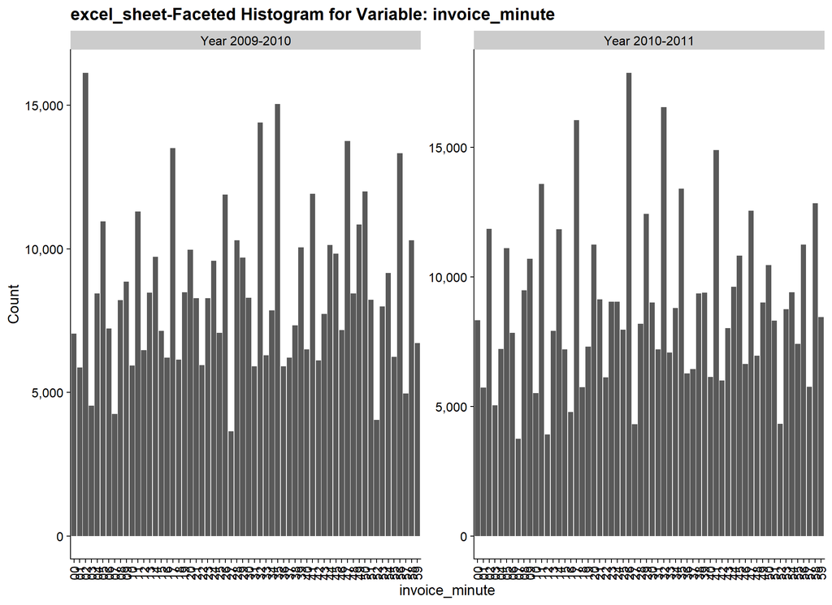

```
## --
## invoice_month
```

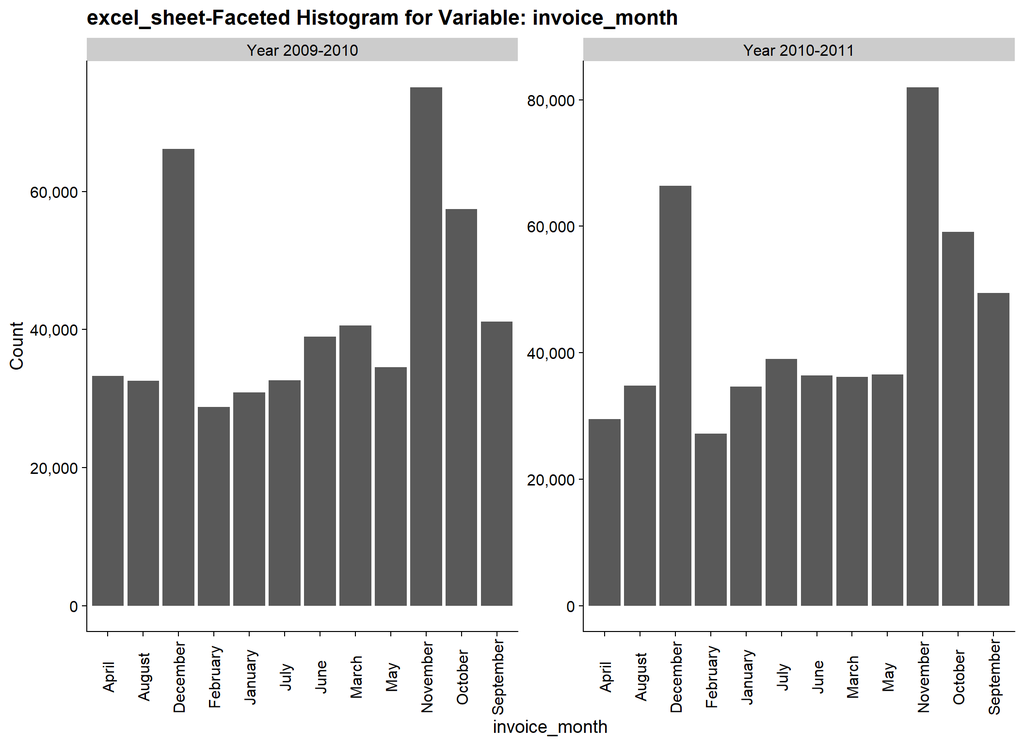

```
## --
## invoice_woy
```

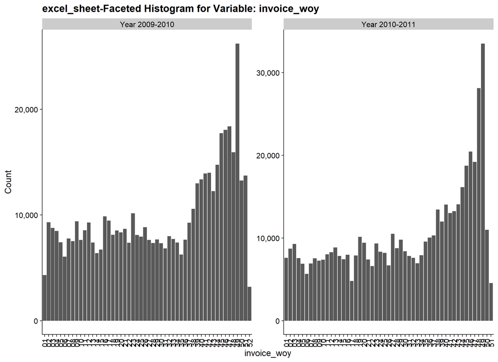

```
## --
## invoice_ym
```

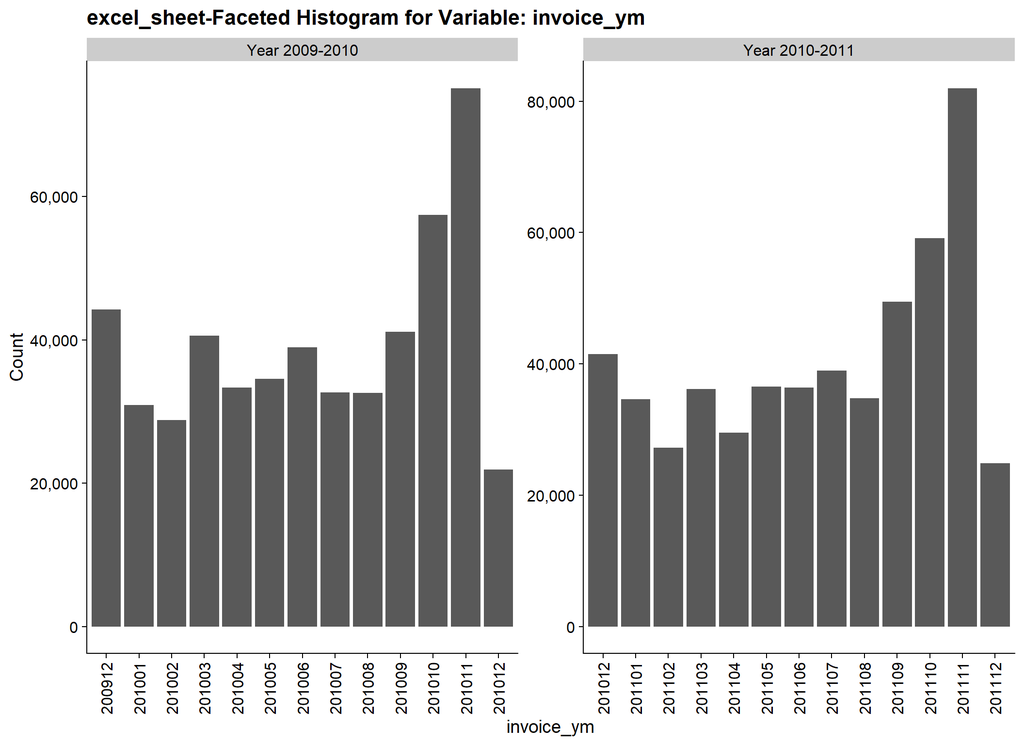

```r
categorical_vars <- categorical_vars[!categorical_vars %in% facet_varname] %>% sort()

for (plot_varname in categorical_vars) {
  cat("--\n")
  cat(str_c(plot_varname, "\n"))

  plot_tbl <- data_tbl %>%
    filter(!are_na(!! plot_varname)) %>%
    mutate(
      varname_trunc = fct_relabel(!! sym(plot_varname), str_trunc, width = 10)
      )

  explore_plot <- ggplot(plot_tbl) +
    geom_bar(aes(x = varname_trunc)) +
    facet_wrap(facet_varname, scales = "free") +
    xlab(plot_varname) +
    ylab("Count") +
    scale_y_continuous(labels = label_comma()) +
    ggtitle(str_c(facet_varname, "-Faceted Histogram for Variable: ",
                  plot_varname)) +
    theme(axis.text.x = element_text(angle = 90, vjust = 0.5))

  plot(explore_plot)
}
```

### 5.1.4 Date/Time Variables

Like the univariate plots, we facet on histograms of the years in the dates.

```
## --
## invoice_date
```

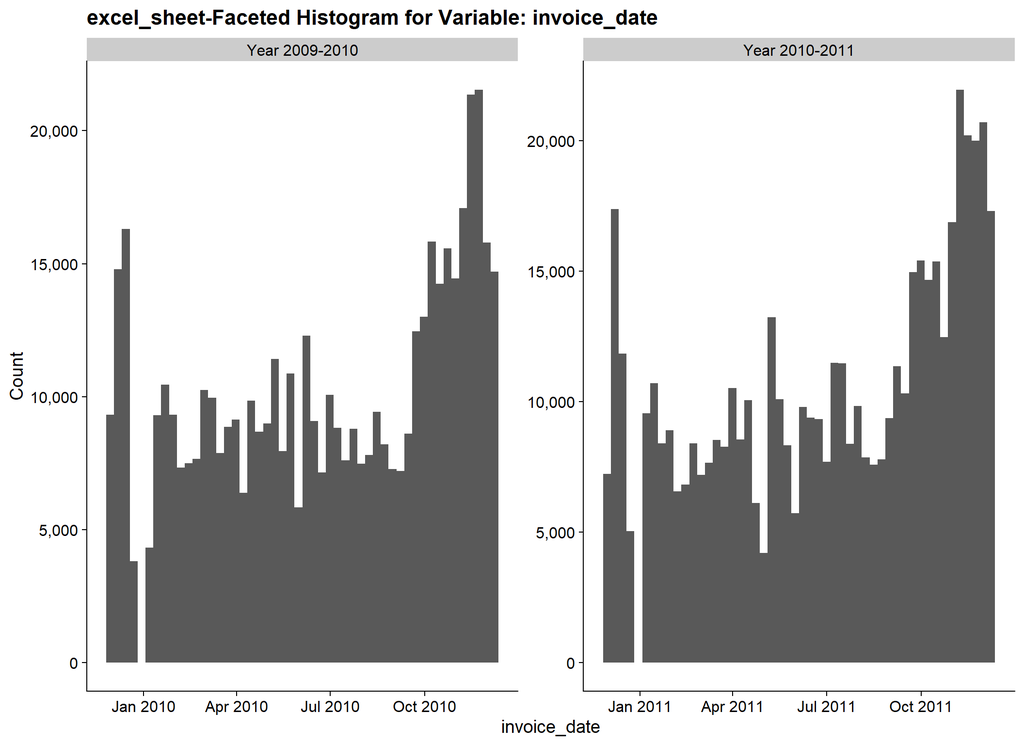

```
## --
## invoice_dttm
```

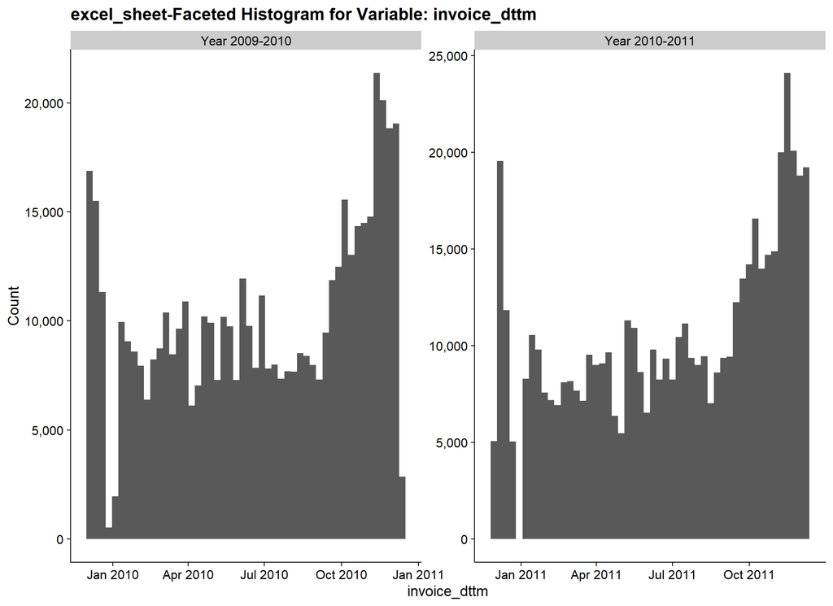

```r
for (plot_varname in datetime_vars) {
  cat("--\n")
  cat(str_c(plot_varname, "\n"))

  plot_tbl <- data_tbl %>% filter(!are_na(!! plot_varname))

  explore_plot <- ggplot(plot_tbl) +
    geom_histogram(aes(x = !! sym(plot_varname)),
                   bins = hist_bins_count) +
    facet_wrap(facet_varname, scales = "free") +
    xlab(plot_varname) +
    ylab("Count") +
    scale_y_continuous(labels = label_comma()) +
    ggtitle(str_c(facet_varname, "-Faceted Histogram for Variable: ",
                  plot_varname))

  plot(explore_plot)
}
```

# 6 Custom Explorations

## 6.1 Explore Aggregate Amounts

We now turn our focus to aggregating the data set in various ways and inspect how these aggregate totals are distributed.

### 6.1.1 Invoice-Level Amounts

We first aggregate the data at the invoice level, and inspect how those amounts are distributed.

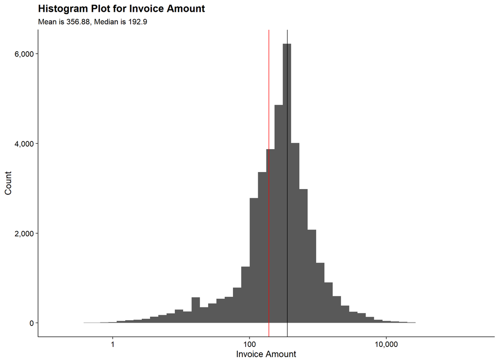

```r
invoice_data_tbl <- data_tbl %>%
  group_by(invoice_id) %>%
  summarise(
    .groups = "drop",

    invoice_amount = sum(price * quantity)
  )

invoice_mean   <- invoice_data_tbl %>% pull(invoice_amount) %>% mean()   %>% round(2)
invoice_median <- invoice_data_tbl %>% pull(invoice_amount) %>% median() %>% round(2)

ggplot(invoice_data_tbl) +
  geom_histogram(aes(x = invoice_amount), bins = 50) +
  geom_vline(aes(xintercept = invoice_mean),   colour = "black") +
  geom_vline(aes(xintercept = invoice_median), colour = "red") +
  xlab("Invoice Amount") +
  ylab("Count") +
  scale_x_log10(labels = label_comma()) +
  scale_y_continuous(labels = label_comma()) +
  ggtitle(
    label    = "Histogram Plot for Invoice Amount",
    subtitle = glue("Mean is {invoice_mean}, Median is {invoice_median}")
    )
```

We see there is a broad range of different invoice totals, with mean and median being a few hundred pounds.